# Ilha Josina Ivermectin Trial

Preliminary report: cluster enumeration and delineation

Joe Brew and Carlos Chaccour

2017-04-30

# Context

This document is a first step in analyzing the feasibility of carrying out an Ivermectin trial in the area of Ilha Josina, District of Manhiça, Province of Maputo, Mozambique. Its objective is to quantify how many clusters of 50 children (age < 5) could be formed, if each of those clusters had a “buffer” of 1 kilometers (ie, minimum distance of 2 kilometers) between two children of two different buffers.

# Methods

Census data were used, with a snapshot from May 6, 2016. Residents of Ilha Josina were identified through polgyonal overlay with publicly avaiable administrative shapefiles. Those who were < 5 years of age as of the snapshot date were considered eligible.

A custom algorithm was devised for division into clusters. The algorithm took as parameters multiple different “strategies” for creating clusters (centroid-based, “random walk” based, etc.). A simulations-based approach was used to identify the optimal strategy for the case of Ilha Josina.

“Optimal” being the maximum number of children/clusters meeting the buffering and age requirements.

Full code for the algorithm and its implementation is available online.

https://github.com/joebrew/ilha_josina

# Results

Our cluster centroids can be viewed below.

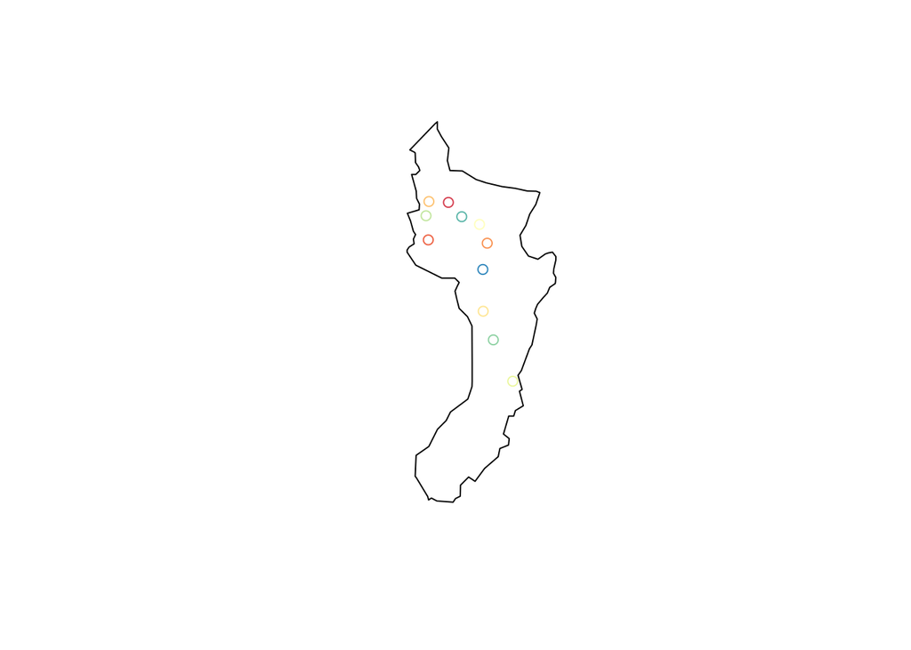

The below plot shows the actual boundaries of our clusters, with buffers.

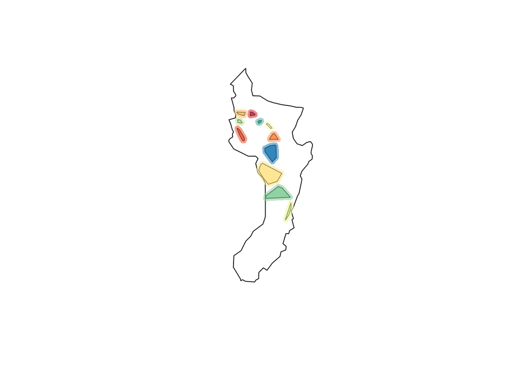

The below interactive map shows all clusters, buffers, and child residents. Points are children, colored by their respective clusters. Grey points are children residing outside of core cluster areas (ie, buffers or unclusterable). Thick lines show cluster borders; thin lines show cluster buffer boundaries.

[interactive chart not shown]

# Assignation to intervention

We randomly assign all 11 clusters to be of either “intervention” or “control” status. The assignments can be seen below.

| cluster | status |
| --- | --- |
| 1 | control |
| 2 | intervention |
| 3 | intervention |
| 4 | control |
| 5 | intervention |
| 6 | intervention |
| 7 | control |
| 8 | intervention |
| 9 | intervention |
| 10 | control |
| 11 | control |

# Voronoi tesselation

In order both to (a) expand our cluster boundaries to the maximum possible size and (b) create “implementation” zones (ie, areas defined by whether they receive the intervention or not), we perform Delaunay triangulation / Voroni tesselation.

Having carried out the polygon delineation, we plot the clusters with expanded borders.

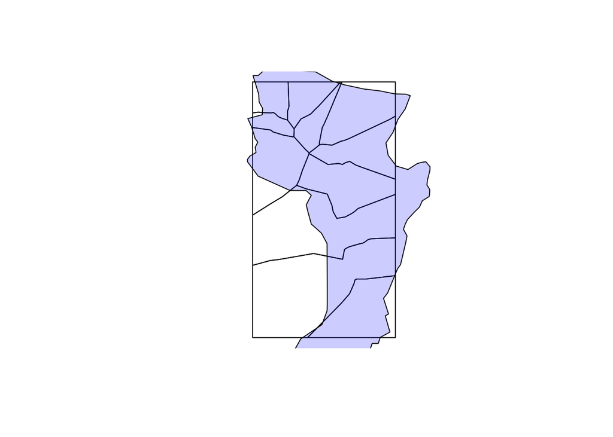

In the above, our methodology works well within Ilha Josina; but at borders, our neighborhoods expand infinitely outwards. In order to account for this, we can trim our polygons to keep only those segments which fall into Ilha Josina.

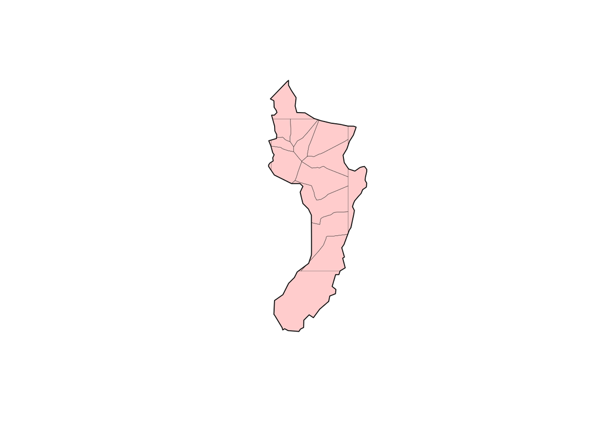

The below interactive map allows for manual examination of clusters. Click on any polygon to reveal its cluster number and intervention status.

[interactive chart not shown]

# Defining intervention zones.

Having expanded borders, we can re-calculate buffers based not on cluster number but on intervention status (since there is no need for a buffer between two clusters of identical intervention status).

To do this, we first “dissolve” our polygons by intervention status. This means removing boundaries between areas of the same intervention status. This results in the following intrevention zones (red = intervention; green = control).

[interactive chart not shown]

We then use spatial buffering to re-define our buffers, going inwards 1,000 meters from the “dissolved” boundaries.

[interactive chart not shown]

## Data products

Having finished our implementation of cluster delineation, we write software-agnostic shapefiles. The purpose of this step is to remove the data products (cluster and buffer delineations) from this report, so that others can use these clusters, regardless of their GIS software.

We create 3 data products.

### 1. `ij_clusters`

`ij_clusters` is a projected shapefile with the exact boundaries between clusters. It is downloadable from: https://github.com/joebrew/ilha_josina/tree/master/data_products/ij_clusters

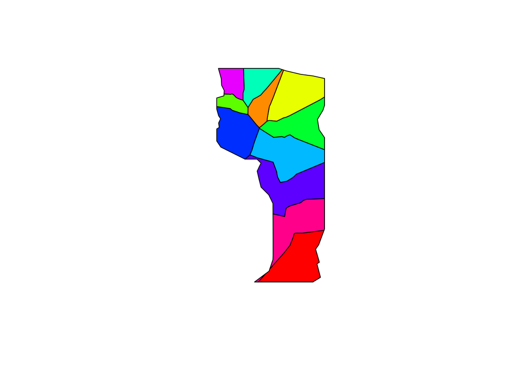

### 2. `ij_intervention_zones`

`ij_intervention_zones` is a projected shapefile with the exact boundaries of the intervention zones. It is downloadble from: https://github.com/joebrew/ilha_josina/tree/master/data_products/ij_intervention_zones

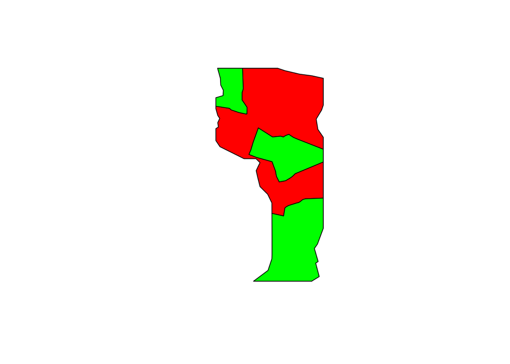

### 3. `ij_intervention_zones_buffered`

`ij_intervention_zones_buffered` is a projected shapefile with the exact boundaries of the intervention zones with a -1000 meter inward buffer added to each zone. It is downloadable from: https://github.com/joebrew/ilha_josina/tree/master/data_products/ij_intervention_zones_buffered

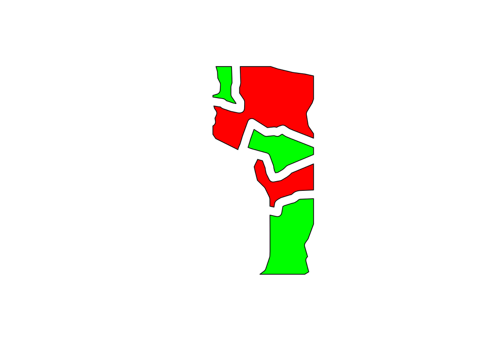

# Increased catchment

Though our dissolution method does not increase our number of clusters, it *does* increase the catchment of each area. Whereas our previous population size was 550, having dissolved unecessary boundaries, we increase our estimated non-buffer population size by 296 to 846. In reality, given population growth since the time of the census, this figure may even be higher.

The below map shows intervention assignments. Small dots represent children. Small dots in a triangle represent children who were originally considered to be in buffer areas (when buffers were drawn at the cluster level), but are now in “core” areas (when buffers are drawn at the intervention zone level).

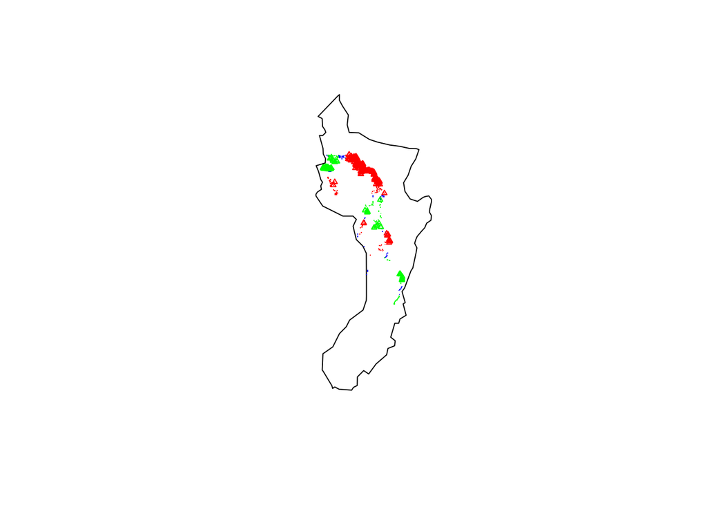

# Details

All code for the methods discussed in this report is downloadable at: https://github.com/joebrew/ilha_josina/tree/master/reports/how_many_clusters